# Exploratory Data Analysis

# 1 Personal Information

Name: Alexandra de Nooy  
Student ID: 14581728  
Email: alexandra.de.nooy@student.uva.nl or denooy.alex@gmail.com  
Submitted on: 22/03/2023  
Github link: https://github.com/adenooy2/MSc-Thesis.git

# 2 Data Context

This exploratory data analysis is conducted usinf R and RStudio. There are two main sets of data to be considered, linked to the two main sections of the project.

The second data set consists of TB burden estimates for Kenya produced by the World Heath Organization (WHO) as well as the accompanying data dictionary. The estimates cover a range of data variables and their estimated values between the years 2000 and 2022. Several key variables include estimates on TB incidence (new cases), notifications (diagnoses) and deaths. Estimates are also provided for different groups of individuals (for example HIV postive patients) and for different tpes of TB.

# 3 Data Description: Baseline TB model

## 3.1 Load baseline data

```r
print(paste("Number of baseline files: " ,num_files,sep=""))
```

```
[1] "Number of baseline files: 5"
```

## 3.2 Explore variables and format of one baseline file

Each baseline data file represents a population of individuals (one per row) and various columns representing the different states or points in the patient pathway reached by each individual.

### 3.2.1 File Structure

```r
#Type of each column
sapply(b_data, class)
```

```
                         hiv                         rnum                    tb_status                   tb_present                   rif_status
                   "numeric"                    "numeric"                  "character"                    "numeric"                    "numeric"
                  num_visits                 patient_time                 tb_seek_care                    do_triage                  tb_screened
                   "numeric"                    "numeric"                    "numeric"                    "numeric"                    "numeric"
                 sens_screen                  spec_screen                screen_result              do_confirmatory                   tb_triaged
                   "numeric"                    "numeric"                    "logical"                    "numeric"                    "numeric"
                 sens_triage                  spec_triage             tb_triage_result      tb_confirmatory_offered  patient_referred_for_sample
                   "numeric"                    "numeric"                    "logical"                    "numeric"                    "numeric"
 patient_reached_sample_site                    conf_test                    spec_conf                    sens_conf                     rif_sens
                   "numeric"                  "character"                    "numeric"                    "numeric"                    "numeric"
                    rif_spec         conf_sample_provided conf_initial_sample_provided           conf_sample_status           conf_sample_tested
                   "numeric"                    "numeric"                    "numeric"                    "numeric"                    "numeric"
        conf_sample_referred           conf_sample_result patient_conf_result_received      conf_res_same_encounter             emp_notification
                   "numeric"                    "numeric"                    "numeric"                    "numeric"                    "numeric"
```

Notably there are many columns in the dataframe listed as numeric, but only have values 0-1

### 3.2.2 Missing Data

The code below highlights only a few columns with missing data. These columns all relate to the result of a TB test ( screen_result, tb_triage_result, conf_sample_result, patient_conf_result_received). In the design of the baseline model, these missing values are not as a result of data being incorrcetly recorded or collected, but rather represent a status themselves - that is, no result was availble at that point in the patient pathway

```r
sapply(b_data, function(x) sum(is.na(x)))
```

```
                         hiv                         rnum                    tb_status                   tb_present                   rif_status
                           0                            0                            0                            0                            0
                  num_visits                 patient_time                 tb_seek_care                    do_triage                  tb_screened
                           0                            0                            0                            0                            0
                 sens_screen                  spec_screen                screen_result              do_confirmatory                   tb_triaged
                           0                            0                        10000                            0                            0
                 sens_triage                  spec_triage             tb_triage_result      tb_confirmatory_offered  patient_referred_for_sample
                           0                            0                        10000                            0                            0
 patient_reached_sample_site                    conf_test                    spec_conf                    sens_conf                     rif_sens
                           0                            0                            0                            0                            0
                    rif_spec         conf_sample_provided conf_initial_sample_provided           conf_sample_status           conf_sample_tested
                           0                            0                            0                            0                            0
        conf_sample_referred           conf_sample_result patient_conf_result_received      conf_res_same_encounter             emp_notification
                           0                         2371                         2912                            0                            0
```

### 3.2.3 HIV and TB summary

```r
print(paste("Total TB Negative: ", hiv_tb_counts$hiv_neg[hiv_tb_counts$tb_status=="tb_negative"]+hiv_tb_counts$hiv_pos[hiv_tb_counts$tb_status=="tb_negative"],sep=""))
```

```
[1] "Total TB Negative: 9002"
```

### 3.2.4 TB patient pathway summary

Given the format of the model, it is useful to summarise the number of individuals reaching key points in the patient pathway. An initial analysis is conducted only for those people with TB. Based on descriptions of the model, key variables representing some some of these points are: tb_present, tb_seek_care,tb_confirmatory_offered,conf_sample_provided,patient_conf_result_received. Summarising these variables will provide an indiciatio of how many individuals with TB reach each point in the pathway and are diagnoses corrcetly.

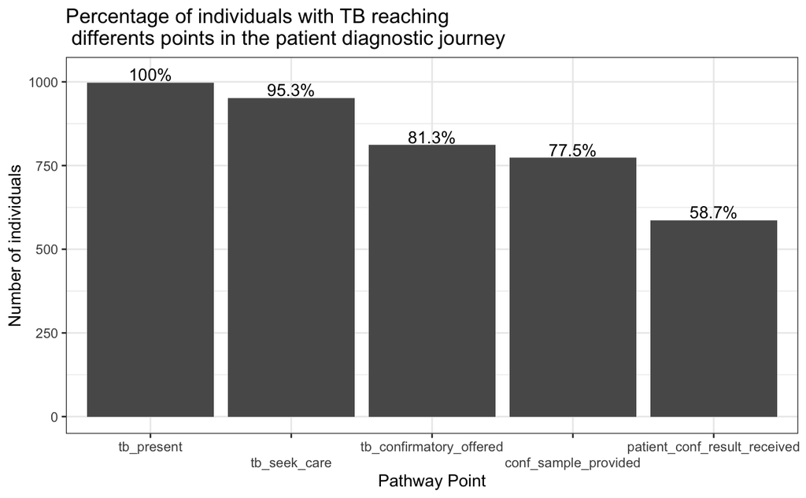

# 4 Data Description: WHO Tuberculosis Data

This dataset represent the WHO TB estimates for Kenya.

## 4.1 Load and merge WHO TB burden data and data dictionary

| country | year | variable_name | value | dataset | definition |
| --- | --- | --- | --- | --- | --- |
| Kenya | 2000 | e_pop_num | 30851606 | Estimates | Estimated total population number |
| Kenya | 2001 | e_pop_num | 31800343 | Estimates | Estimated total population number |
| Kenya | 2002 | e_pop_num | 32779823 | Estimates | Estimated total population number |
| Kenya | 2003 | e_pop_num | 33767122 | Estimates | Estimated total population number |
| Kenya | 2004 | e_pop_num | 34791836 | Estimates | Estimated total population number |

### 4.1.1 Structure of combined dataset and data dictionary

```r
#Type of each column
sapply(tbData, class)
```

```
      country          year variable_name         value       dataset    definition
  "character"     "numeric"   "character"     "numeric"   "character"   "character"
```

##Missing Data

From the code below it is seen that there are no missing data elements in the WHO TB data and every indicator has a value for the year 2000 to 2022.

```r
sapply(tb_estimates, function(x) sum(is.na(x)))
```

```
                 country                     iso2                     iso3              iso_numeric              g_whoregion                     year
                       0                        0                        0                        0                        0                        0
               e_pop_num               e_inc_100k            e_inc_100k_lo            e_inc_100k_hi                e_inc_num             e_inc_num_lo
                       0                        0                        0                        0                        0                        0
            e_inc_num_hi             e_tbhiv_prct          e_tbhiv_prct_lo          e_tbhiv_prct_hi         e_inc_tbhiv_100k      e_inc_tbhiv_100k_lo
                       0                        0                        0                        0                        0                        0
     e_inc_tbhiv_100k_hi          e_inc_tbhiv_num       e_inc_tbhiv_num_lo       e_inc_tbhiv_num_hi    e_mort_exc_tbhiv_100k e_mort_exc_tbhiv_100k_lo
                       0                        0                        0                        0                        0                        0
e_mort_exc_tbhiv_100k_hi     e_mort_exc_tbhiv_num  e_mort_exc_tbhiv_num_lo  e_mort_exc_tbhiv_num_hi        e_mort_tbhiv_100k     e_mort_tbhiv_100k_lo
                       0                        0                        0                        0                        0                        0
    e_mort_tbhiv_100k_hi         e_mort_tbhiv_num      e_mort_tbhiv_num_lo      e_mort_tbhiv_num_hi              e_mort_100k           e_mort_100k_lo
                       0                        0                        0                        0                        0                        0
          e_mort_100k_hi               e_mort_num            e_mort_num_lo            e_mort_num_hi                      cfr                   cfr_lo
                       0                        0                        0                        0                        0                        0
                  cfr_hi                  cfr_pct               cfr_pct_lo               cfr_pct_hi            c_newinc_100k                    c_cdr
                       0                        0                        0                        0                        0                        0
                c_cdr_lo                 c_cdr_hi
                       0                        0
```

### 4.1.2 Exploring WHO variables

Within the dataset there are multiple indicators listed under the column variable_name, each representing a certain measurement or quantity related to TB. Not all of these will be relevant to the model calibration but it is important to see what is available to determine those which are the most useful.

Notably, indicator values are presented yearly over an approximate two decade period between 2000-2022

```r
print(list(tbData_time))
```

```
[[1]]
 [1] 2000 2001 2002 2003 2004 2005 2006 2007 2008 2009 2010 2011 2012 2013 2014 2015 2016 2017 2018 2019 2020 2021 2022
```

## 4.2 Exploring new incident infections (all infections and HIV)

Incident infections are the number of estimated people being infected with and acquiring active TB each year. The number of new infections is an estimate and is different from the number of reported cases or diagnoses - which is reliant on the identification, testing and treating of people with TB. This data represents a key element in the transmisison model and it is important in understanding the past dynamics of TB in kenya and provides an idea on the current trend.

HIV is an important factor to consider, given that Kenya has relatively high HIV/TB coinfection and because HIV impacts the likelihood of contracting TB, becoming infectious or of becoming severely ill.

```r
#select relevant variables related to incidence
inc_data= tbData %>% filter(variable_name %in% c("e_inc_num","e_inc_num_lo","e_inc_num_hi")) %>% mutate(var="e_inc_num")
hiv_inc=tbData %>% filter(variable_name%in% c("e_inc_tbhiv_num","e_inc_tbhiv_num_lo","e_inc_tbhiv_num_hi"))%>% mutate(var="e_inc_tbhiv_num")
hiv_perc_inc=tbData %>% filter(variable_name%in% c("e_tbhiv_prct","e_tbhiv_prct_lo","e_tbhiv_prct_hi"))%>% mutate(var="e_tbhiv_prct")

#label upper, lower and mean estimates
all_inc=rbind(inc_data,hiv_inc)
all_inc$est_type="Mean"
all_inc$est_type[grepl("_lo",all_inc$variable_name,fixed=TRUE)==TRUE]="Lower"
all_inc$est_type[grepl("_hi",all_inc$variable_name,fixed=TRUE)==TRUE]="Upper"

hiv_perc_inc$est_type="Mean"
hiv_perc_inc$est_type[grepl("_lo",hiv_perc_inc$variable_name,fixed=TRUE)==TRUE]="Lower"
hiv_perc_inc$est_type[grepl("_hi",hiv_perc_inc$variable_name,fixed=TRUE)==TRUE]="Upper"

#Incident cases (all and HIV)
ggplot(all_inc,aes(x=year,y=value,group=variable_name,color=est_type))+geom_point()+
  geom_line()+theme_bw()+xlab("Year")+ylab("Number of cases")+
  labs(title="Estimated number of new cases per year")+theme(legend.position = "bottom")+facet_wrap(.~var)

#Percentage of new cases HIV positive
ggplot(hiv_perc_inc,aes(x=year,y=value,group=variable_name,color=est_type))+geom_point()+
  geom_line()+theme_bw()+xlab("Year")+ylab("Number of cases")+
  labs(title="Estimated number of new cases per year")+theme(legend.position = "bottom")+facet_wrap(.~var)
```

[output not shown]

## 4.3 Exploring mean estimates of key factors - population, incidence, case detection, mortality (for whole population)

Key definitions from WHO indicator metadata registry and estimate methedology appendix  
- Case Detection rate (%) : Proportion of estimated new and relapse TB (incident) cases diagnosed in a year  
-Number of deaths: Product of incidence and case fatality rate  
-Case fatality rate: risk of death among people with active (incident) TB, adapte dto account fro low covergae/reporting

```r
#Collect key factors relevant to understanding the dynamics of TB transmission
key_fact=tbData %>% filter(variable_name %in% c("e_pop_num","e_inc_num","e_inc_rr_num","e_mort_num","c_cdr","cfr","cfr_pct")) %>%
  select(variable_name,year,value) %>% spread(variable_name,value)


#Conduct additional caluclations for rates or use rates to estimate numbers
key_fact$calc_cfr_inc=100*(key_fact$e_mort_num/key_fact$e_inc_num)
key_fact$calc_case_detect=key_fact$c_cdr/100*key_fact$e_inc_num
key_fact$calc_cfr_case=100*(key_fact$e_mort_num/key_fact$calc_case_detect)
key_fact$deaths_cal=key_fact$cfr*key_fact$e_inc_num

#Add user friendly labels
variable=c("e_pop_num","e_inc_num","e_inc_rr_num","e_mort_num","c_cdr","cfr","cfr_pct","calc_case_detect")
labels=c("Population","Incident Cases","Incident RR Cases","Deaths","Case Detection Rate","Case fatality Rate","Case Fatality Rate (%)","Cases Detected")
labs=data.frame(cbind(variable,labels))

#Plot key factors with absolute numbers (other than population)
key_fact_num=key_fact %>% select(year,e_inc_num,calc_case_detect,e_mort_num) %>% gather("variable","value",2:4) %>% left_join(labs)
ggplot(key_fact_num,aes(x=year,y=value,group=variable,colour=labels))+geom_point()+geom_line()+theme_bw()+
  labs(title="Number of incident cases, cases detected and deaths")+ylab("Number of individuals")+theme(legend.position = "bottom")

#Plot key factors which are rates
key_fact_rate=key_fact %>% select(year,c_cdr,cfr_pct) %>% gather("variable","value",2:3)%>% left_join(labs)
ggplot(key_fact_rate,aes(x=year,y=value,group=variable,colour=labels))+geom_point()+geom_line()+theme_bw()+
  labs(title="Case detection and case fatality rates over time")+ylab("Percent(%)")+theme(legend.position = "bottom")
```

[output not shown]

## 4.4 Set up calibration data for transmission model

The transmission model will be calibrated against data from this set. In this case incidence data over time will be the key comparator, however, later it will be useful to compare other variables - like cases detected.

```r
#Collect incidence data in correct format - key variables and wide format
cal_data=all_inc %>% select(year, var,est_type,value) %>% spread(est_type,value) %>% filter(var=="e_inc_num")
```

[output not shown]